# DGP Dossier: synth_placebo_tilted

## 1. Identity & Status

| DGP ID | synth_placebo_tilted |
| --- | --- |
| Version | 1.4.0 |
| Status | experimental |
| Difficulty | ★★★★☆ (4/5) |
| Stress Profile | overlap: moderatenoise: gaussianlinearity: lineareffect: constanttarget: both |

## 2. What This DGP Stresses (Intent)

**Intent:** The “Spurious Correlation Trap.” This DGP induces strong (but manageable) linear confounding where treated units have naturally higher outcomes than control units ($p(X)$ aligns with $\mu_0(X)$).

**The Scientific Question:** “Can the estimator distinguish Selection Bias from Treatment Effect?” A naive comparison suggests a strong positive effect. The estimator must vigorously adjust for covariates to recover the true zero. This tests resistance to “Bias Leakage.”

## 3. Identification Assumptions (Explicit)

- Selection on observables holds.
- Overlap is moderately tilted (propensity shifted, but not extreme).
- SUTVA holds.
- Sharp Null: $Y_1 \equiv Y_0$.

## 4. Mathematical Specification

Covariates: $X_1, X_2, X_3, X_4, X_5 \sim \mathcal{N}(0, 1^2)$ independently.

**Outcome (control):**
$$\mu_0(X) = 1 + X_1 + 0.5 X_2$$

**Propensity (tilted):**
$$p(X) = \text{expit}(0.6 X_1 + 0.8
X_2)$$

**Treatment effect (sharp null):**
$$\tau(X) \equiv 0$$

**Noise:**
$$\varepsilon \sim
\mathcal{N}(0, 0.5^2)$$
(Shared noise $Y_1 \equiv Y_0$)

## 5. Oracle Truth Definition

- True ATT is zero by construction.
- True QST is identically zero on the canonical grid.

## 6. Visual Diagnostics (n = 5000)

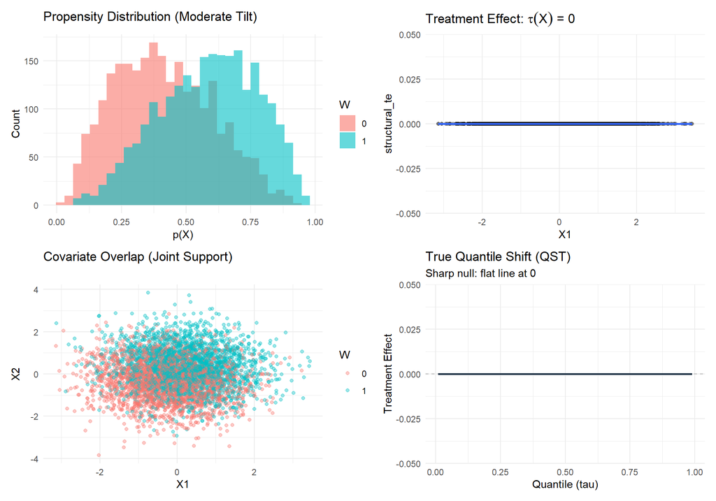

## 7. Empirical Validation

We validate only the oracle estimator to keep builds fast.

Oracle validation (n=1000, seeds=1:20)

| mean_bias | rmse |
| --- | --- |
| 0 | 0 |

## 8. Failure Mode Summary

- **Bias Leakage:** The primary failure mode is reporting a positive effect (Type I error) because the estimator failed to fully scrub the confounding.
- **Under-adjustment:** Regularized estimators (like Lasso) might over-shrink coefficients, leaving residual confounding that masquerades as a treatment effect.

## 9. Implementation Reference

- Code: `R/dgp-synth-placebo-tilted.R` (v1.4.0)
- Registry: `cs_dgp_registry()` entry for `synth_placebo_tilted`
- Oracle: `true_att = 0`, `true_qst = 0`
- Oracle QST: `cs_get_oracle_qst("synth_placebo_tilted", version = "1.4.0")`

## 10. Validation Checklist

- Sharp null enforced ($Y_1 \equiv Y_0$)
- Structural ATT = 0
- QST truth is identically zero
- Oracle validation passes

## 11. Changelog

- v1.0 dossier: Initial placebo dossier
- v1.4.0: Reduced tilt coefficients to 0.6/0.8. v1.3.0 deprecated to avoid confounding variance explosion with bias.

## Appendix: Implementation

```
Source code for: dgp_synth_placebo_tilted_v140

function(n, seed = NULL, include_truth = TRUE, oracle_only = FALSE) {
  if (!is.null(seed)) {
    cs_set_rng(seed)
  }

  X1 <- stats::rnorm(n, mean = 0, sd = 1)
  X2 <- stats::rnorm(n, mean = 0, sd = 1)
  X3 <- stats::rnorm(n, mean = 0, sd = 1)
  X4 <- stats::rnorm(n, mean = 0, sd = 1)
  X5 <- stats::rnorm(n, mean = 0, sd = 1)

  mu0 <- 1 + X1 + 0.5 * X2
  tau <- rep(0, n)

  p <- stats::plogis(0.6 * X1 + 0.8 * X2)
  w <- stats::rbinom(n, size = 1L, prob = p)

  eps <- stats::rnorm(n, mean = 0, sd = 0.5)

  y0 <- mu0 + eps
  y1 <- y0
  if (isTRUE(oracle_only)) {
    return(list(df = tibble::tibble(w = w, y0 = y0, y1 = y1)))
  }
  y  <- ifelse(w == 1L, y1, y0)

  true_att <- cs_true_att(structural_te = tau, w = w)
  true_qst <- if (isTRUE(include_truth)) cs_get_oracle_qst("synth_placebo_tilted", version = "1.4.0") else NULL

  out <- list(
    df = tibble::tibble(
      y  = y,
      w  = w,
      y0 = y0,
      y1 = y1,
      p  = p,
      structural_te = tau,
      X1 = X1,
      X2 = X2,
      X3 = X3,
      X4 = X4,
      X5 = X5
    ),
    true_att = true_att,
    true_qst = true_qst,
    meta = list(
      dgp_id        = "synth_placebo_tilted",
      version       = "1.4.0",
      type          = "synthetic",
      params        = list(n = n, seed = seed),
      structural_te = tau
    )
  )

  cs_check_dgp_synthetic(out)
  out
}
<bytecode: 0x000001d55a73e2a8>
<environment: namespace:CausalStress>
```